# HW05

Author

Lina Sinsheimer

## Question 1

```r
library(ggplot2)
library(dplyr)
library(tidyverse)

twitch_data <- read_csv("https://raw.githubusercontent.com/vaiseys/dav-course/main/Data/twitchdata-update.csv")
```

```r
library(janitor)
twitch_data <- clean_names(twitch_data)

colnames(twitch_data)
```

```
 [1] "channel"             "watch_time_minutes"  "stream_time_minutes"
 [4] "peak_viewers"        "average_viewers"     "followers"
 [7] "followers_gained"    "views_gained"        "partnered"
[10] "mature"              "language"
```

```r
fiverandom <- twitch_data %>% sample_n(5)
summary(fiverandom)
```

```
   channel          watch_time_minutes  stream_time_minutes  peak_viewers
 Length:5           Min.   :1.500e+08   Min.   : 81960      Min.   :  6787
 Class :character   1st Qu.:1.735e+08   1st Qu.:165945      1st Qu.:  6981
 Mode  :character   Median :2.808e+08   Median :184845      Median :  8838
                    Mean   :1.427e+09   Mean   :202053      Mean   : 69643
                    3rd Qu.:4.374e+08   3rd Qu.:211845      3rd Qu.: 14610
                    Max.   :6.092e+09   Max.   :365670      Max.   :310998
 average_viewers   followers       followers_gained   views_gained
 Min.   :  465   Min.   : 124835   Min.   :  15713   Min.   : 2185519
 1st Qu.: 1649   1st Qu.: 169973   1st Qu.:  25768   1st Qu.: 5330221
 Median : 1845   Median : 173713   Median :  29861   Median : 8660860
 Mean   : 6383   Mean   :1195739   Mean   : 305764   Mean   :23776856
 3rd Qu.: 2348   3rd Qu.: 200012   3rd Qu.:  87295   3rd Qu.:13001718
 Max.   :25610   Max.   :5310163   Max.   :1370184   Max.   :89705964
 partnered        mature          language
 Mode:logical   Mode :logical   Length:5
 TRUE:5         FALSE:4         Class :character
                TRUE :1         Mode  :character
```

When there is a higher number of followers, there is also typically a higher number of average viewers.

```r
avgview_followers <- twitch_data %>%
   select(average_viewers, followers)

summary(avgview_followers)
```

```
 average_viewers    followers
 Min.   :   235   Min.   :   3660
 1st Qu.:  1458   1st Qu.: 170546
 Median :  2425   Median : 318063
 Mean   :  4781   Mean   : 570054
 3rd Qu.:  4786   3rd Qu.: 624332
 Max.   :147643   Max.   :8938903
```

The mean of average viewers is 4781, while the mean of followers is 570054. This is interesting because even though the follower count may be high, it does not always indicate that all of your followers will watch the video, hence the average viewers not being equal to the followers.

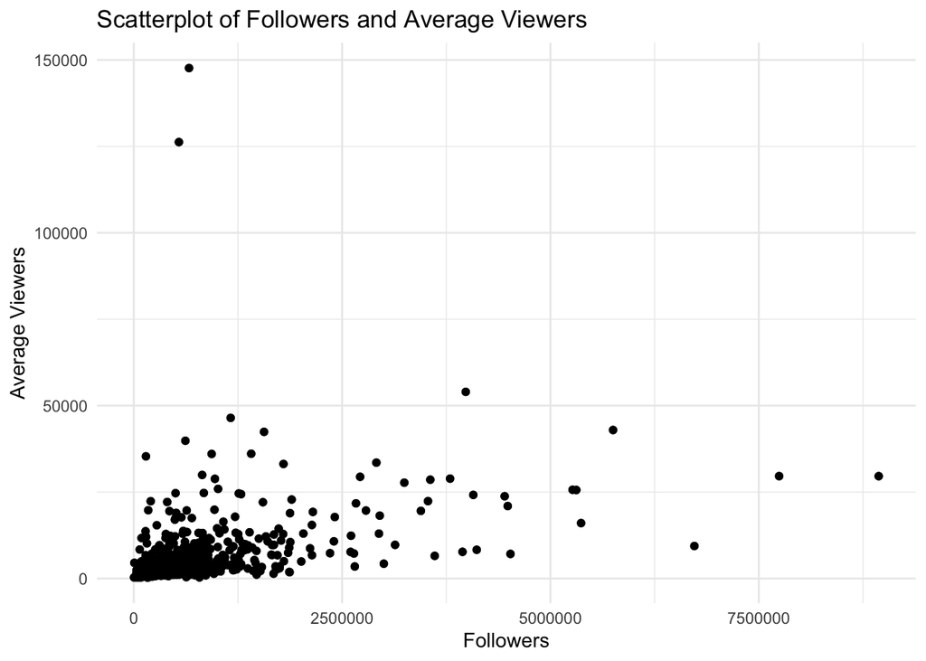

```r
library(ggplot2)

ggplot(twitch_data, aes(x = followers, y = average_viewers)) +
  geom_point() +
  geom_jitter() +
  labs(title = "Scatterplot of Followers and Average Viewers",
       x = "Followers",
       y = "Average Viewers") +
    theme_minimal(
    )
```

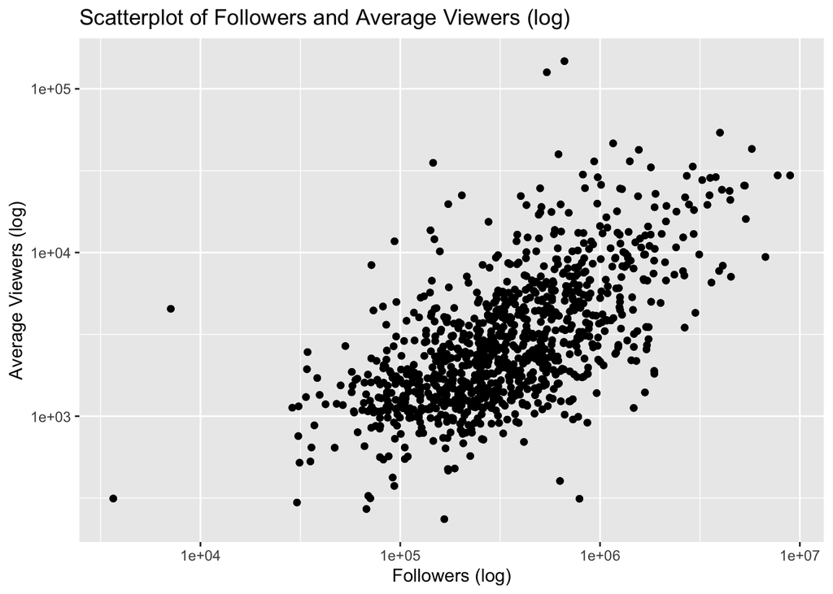

```r
library(ggplot2)

ggplot(twitch_data, aes(x = followers, y = average_viewers)) +
  geom_point() +
  geom_jitter() +
  scale_x_log10() +
  scale_y_log10() +
  labs(title = "Scatterplot of Followers and Average Viewers (log)",
       x = "Followers (log)",
       y = "Average Viewers (log)")
```

```r
twitch_data <- twitch_data %>%
  mutate(log_viewers = log10(average_viewers),
         log_followers = log10(followers))
```

For the first graph, it is hard to understand the relationship between the two variables, as most of the data is packed in the bottom left of the graph. The second graph shows the correlation much more clearly. It does look like it is a positive correlation.

## Question 2

```r
fit1 <- lm(log_viewers ~ log_followers, data = twitch_data)
```

```r
library(broom)
tidyfit <- tidy(fit1)
```

```r
tidy(fit1)
```

```
# A tibble: 2 × 5
  term          estimate std.error statistic   p.value
  <chr>            <dbl>     <dbl>     <dbl>     <dbl>
1 (Intercept)      0.198    0.125       1.58 1.15e-  1
2 log_followers    0.588    0.0226     26.0  1.69e-114
```

## Question 3

```r
library(broom)
pred_data <- augment(fit1)

glimpse(pred_data)
```

```
Rows: 1,000
Columns: 8
$ log_viewers   <dbl> 4.442731, 4.408410, 4.040444, 3.887280, 4.471321, 4.6275…
$ log_followers <dbl> 6.511388, 6.725108, 6.247393, 6.596030, 6.951284, 6.1940…
$ .fitted       <dbl> 4.029761, 4.155534, 3.874400, 4.079572, 4.288638, 3.8430…
$ .resid        <dbl> 0.4129697, 0.2528757, 0.1660436, -0.1922928, 0.1826833, …
$ .hat          <dbl> 0.006194481, 0.008694557, 0.003782169, 0.007126066, 0.01…
$ .sigma        <dbl> 0.3085580, 0.3087321, 0.3087919, 0.3087764, 0.3087820, 0…
$ .cooksd       <dbl> 0.0056128779, 0.0029688873, 0.0005513456, 0.0014026033, …
$ .std.resid    <dbl> 1.3420109, 0.8227954, 0.5389316, -0.6251793, 0.5953620, …
```

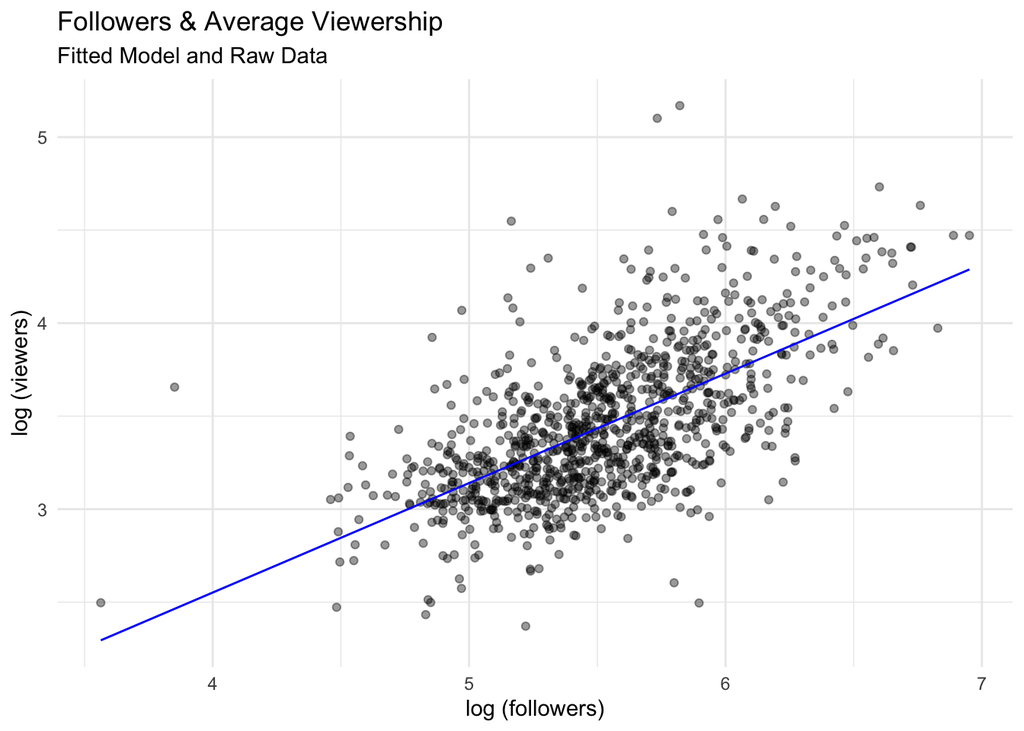

```r
pred_data %>%
  ggplot(aes(x = log_followers,
             y = log_viewers)) +
  geom_jitter(alpha = 0.4) +
  geom_line(aes(x = log_followers,
                y = .fitted),
            col = "blue") +
  theme_minimal() +
  labs(subtitle = "Fitted Model and Raw Data",
       title = "Followers & Average Viewership",
       x = "log (followers)",
       y = "log (viewers)")
```

I do think that this model appropriately describes the relationship.

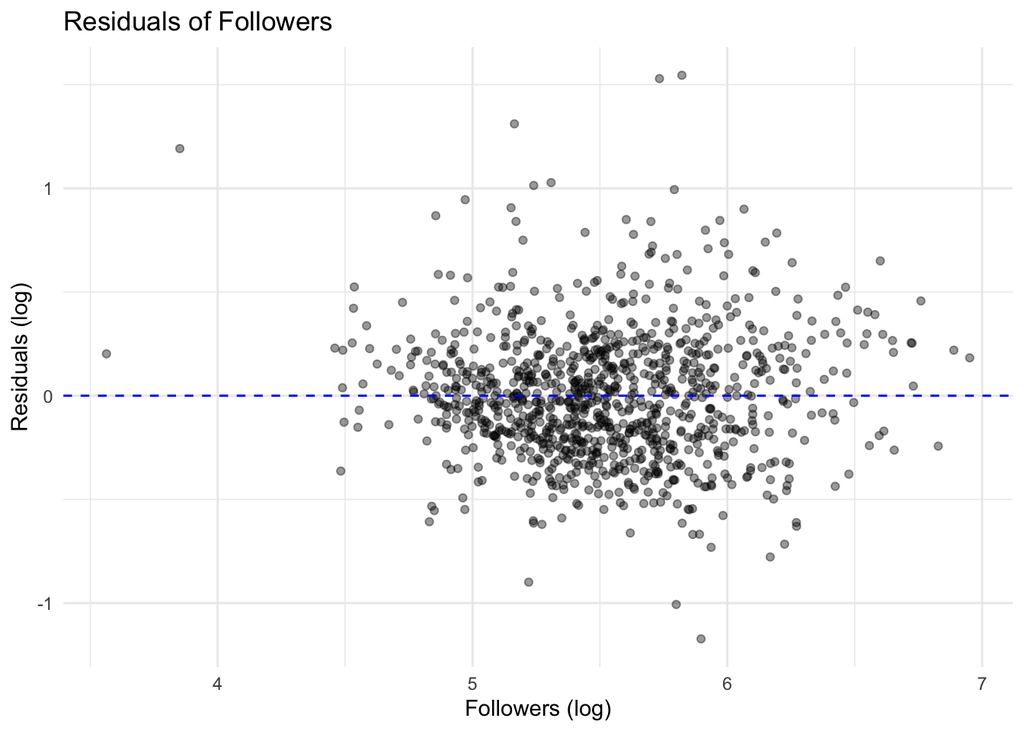

```r
pred_data %>%
  ggplot(aes(x = log_followers,
             y = .resid)) +
  geom_jitter(alpha = 0.4)  +
  geom_hline(yintercept = 0, linetype = "dashed", color = "blue") +
  theme_minimal() +
  labs(
       title = "Residuals of Followers",
       x = "Followers (log)",
       y = "Residuals (log)")
```

## Question 4

```r
glimpse(twitch_data)
```

```
Rows: 1,000
Columns: 13
$ channel             <chr> "xQcOW", "summit1g", "Gaules", "ESL_CSGO", "Tfue",…
$ watch_time_minutes  <dbl> 6196161750, 6091677300, 5644590915, 3970318140, 36…
$ stream_time_minutes <dbl> 215250, 211845, 515280, 517740, 123660, 82260, 136…
$ peak_viewers        <dbl> 222720, 310998, 387315, 300575, 285644, 263720, 11…
$ average_viewers     <dbl> 27716, 25610, 10976, 7714, 29602, 42414, 24181, 18…
$ followers           <dbl> 3246298, 5310163, 1767635, 3944850, 8938903, 15634…
$ followers_gained    <dbl> 1734810, 1370184, 1023779, 703986, 2068424, 554201…
$ views_gained        <dbl> 93036735, 89705964, 102611607, 106546942, 78998587…
$ partnered           <lgl> TRUE, TRUE, TRUE, TRUE, TRUE, TRUE, TRUE, TRUE, TR…
$ mature              <lgl> FALSE, FALSE, TRUE, FALSE, FALSE, FALSE, FALSE, FA…
$ language            <chr> "English", "English", "Portuguese", "English", "En…
$ log_viewers         <dbl> 4.442731, 4.408410, 4.040444, 3.887280, 4.471321, …
$ log_followers       <dbl> 6.511388, 6.725108, 6.247393, 6.596030, 6.951284, …
```

```r
summary(twitch_data)
```

```
   channel          watch_time_minutes  stream_time_minutes  peak_viewers
 Length:1000        Min.   :1.222e+08   Min.   :  3465      Min.   :   496
 Class :character   1st Qu.:1.632e+08   1st Qu.: 73759      1st Qu.:  9114
 Mode  :character   Median :2.350e+08   Median :108240      Median : 16676
                    Mean   :4.184e+08   Mean   :120515      Mean   : 37065
                    3rd Qu.:4.337e+08   3rd Qu.:141844      3rd Qu.: 37570
                    Max.   :6.196e+09   Max.   :521445      Max.   :639375
 average_viewers    followers       followers_gained   views_gained
 Min.   :   235   Min.   :   3660   Min.   : -15772   Min.   :   175788
 1st Qu.:  1458   1st Qu.: 170546   1st Qu.:  43758   1st Qu.:  3880602
 Median :  2425   Median : 318063   Median :  98352   Median :  6456324
 Mean   :  4781   Mean   : 570054   Mean   : 205519   Mean   : 11668166
 3rd Qu.:  4786   3rd Qu.: 624332   3rd Qu.: 236131   3rd Qu.: 12196762
 Max.   :147643   Max.   :8938903   Max.   :3966525   Max.   :670137548
 partnered         mature          language          log_viewers
 Mode :logical   Mode :logical   Length:1000        Min.   :2.371
 FALSE:22        FALSE:770       Class :character   1st Qu.:3.164
 TRUE :978       TRUE :230       Mode  :character   Median :3.385
                                                    Mean   :3.450
                                                    3rd Qu.:3.680
                                                    Max.   :5.169
 log_followers
 Min.   :3.563
 1st Qu.:5.232
 Median :5.503
 Mean   :5.527
 3rd Qu.:5.795
 Max.   :6.951
```

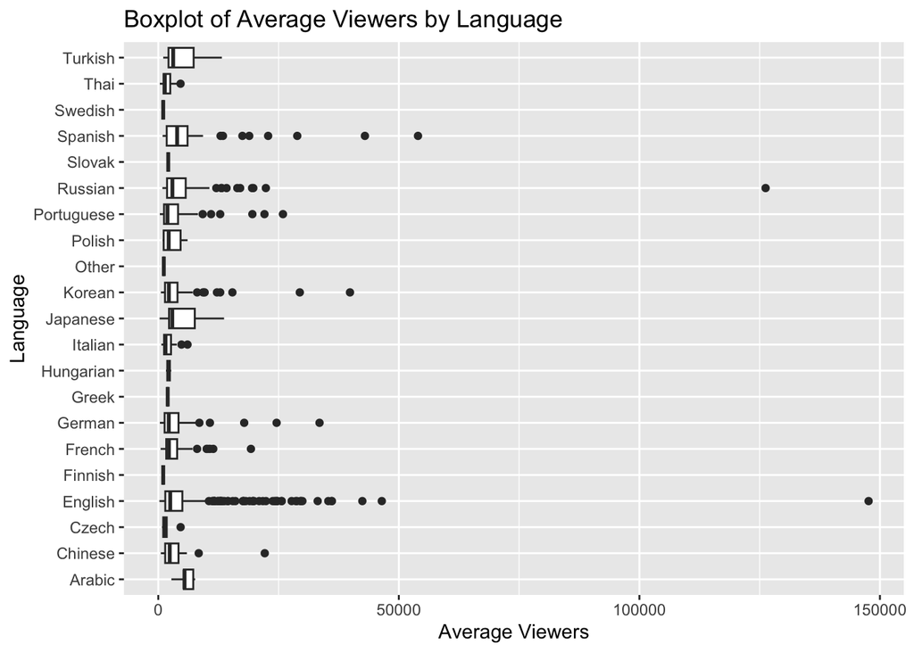

```r
library(ggplot2)

ggplot(twitch_data, aes(x = language, y = average_viewers)) +
  geom_boxplot() +
  coord_flip() +
  labs(title = "Boxplot of Average Viewers by Language",
       x = "Language",
       y = "Average Viewers")
```

## Question 5

```r
twitch_data <- twitch_data %>%
  mutate(language = as.factor(language),
         language = relevel(language, ref = "English"))
```

```r
twitchlm <- lm(average_viewers ~ language, data = twitch_data)
tidy(twitchlm)
```

```
# A tibble: 21 × 5
   term              estimate std.error statistic  p.value
   <chr>                <dbl>     <dbl>     <dbl>    <dbl>
 1 (Intercept)          5113.      385.    13.3   3.47e-37
 2 languageArabic        569.     3808.     0.150 8.81e- 1
 3 languageChinese     -1688.     1594.    -1.06  2.90e- 1
 4 languageCzech       -3285.     3480.    -0.944 3.45e- 1
 5 languageFinnish     -4086.     8480.    -0.482 6.30e- 1
 6 languageFrench      -1606.     1111.    -1.45  1.49e- 1
 7 languageGerman       -835.     1270.    -0.657 5.11e- 1
 8 languageGreek       -3152.     8480.    -0.372 7.10e- 1
 9 languageHungarian   -2972.     6002.    -0.495 6.21e- 1
10 languageItalian     -2907.     2090.    -1.39  1.65e- 1
# ℹ 11 more rows
```

## Question 6

```r
language <- lm(average_viewers ~ language, data = twitch_data)
twitch_data2 <- augment(language)

glimpse(language)
```

[output not shown]

```r
summary(twitch_data2)
```

```
 average_viewers        language      .fitted         .resid
 Min.   :   235   English   :485   Min.   :1027   Min.   : -5745.2
 1st Qu.:  1458   Korean    : 77   1st Qu.:3914   1st Qu.: -3316.8
 Median :  2425   Russian   : 74   Median :5113   Median : -2047.5
 Mean   :  4781   Spanish   : 68   Mean   :4781   Mean   :     0.0
 3rd Qu.:  4786   French    : 66   3rd Qu.:5113   3rd Qu.:   172.8
 Max.   :147643   Portuguese: 61   Max.   :6594   Max.   :142530.2
                  (Other)   :169
      .hat              .sigma        .cooksd           .std.resid
 Min.   :0.002062   Min.   :7142   Min.   :0.000000   Min.   :-0.68286
 1st Qu.:0.002062   1st Qu.:8474   1st Qu.:0.000011   1st Qu.:-0.39335
 Median :0.012987   Median :8475   Median :0.000023   Median :-0.24484
 Mean   :0.021000   Mean   :8471   Mean   :0.000381   Mean   : 0.00000
 3rd Qu.:0.015152   3rd Qu.:8475   3rd Qu.:0.000099   3rd Qu.: 0.02131
 Max.   :1.000000   Max.   :8475   Max.   :0.131899   Max.   :16.84319
                                   NA's   :5          NA's   :5
```

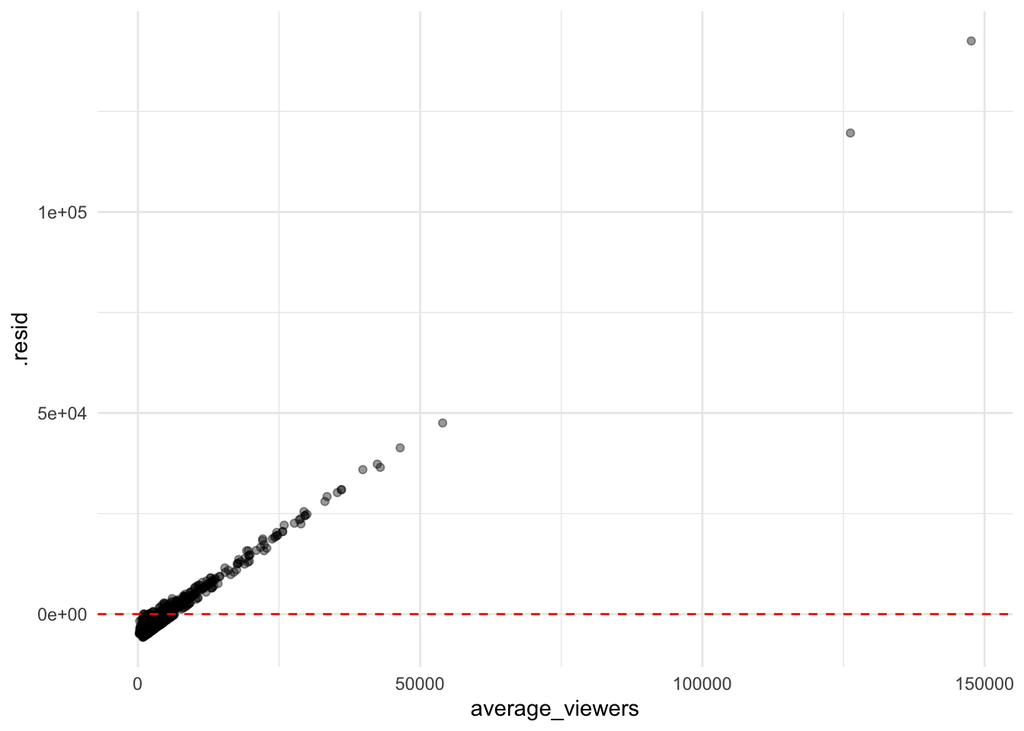

```r
twitch_data2 %>%
  ggplot(aes(x = average_viewers,
             y = .resid)) +
  geom_jitter(alpha = 0.4)  +
  geom_hline(yintercept = 0, linetype = "dashed", color = "red") +
  theme_minimal() +
  scale_x_log10() +
  scale_x_continuous()
```

```r
  labs(
       title = "Scatterplot of Followers & Residuals",
       x = "Followers (log)",
       y = "Residuals (log)")
```

```
$x
[1] "Followers (log)"

$y
[1] "Residuals (log)"

$title
[1] "Scatterplot of Followers & Residuals"

attr(,"class")
[1] "labels"
```

```r
twitch_data2 %>%
  filter(.resid > 25000 | .resid < -25000)
```

```
# A tibble: 13 × 8
   average_viewers language .fitted  .resid    .hat .sigma .cooksd .std.resid
             <dbl> <fct>      <dbl>   <dbl>   <dbl>  <dbl>   <dbl>      <dbl>
 1           42414 English    5113.  37301. 0.00206  8391. 0.00191       4.41
 2           42948 Spanish    6450.  36498. 0.0147   8393. 0.0134        4.34
 3           53986 Spanish    6450.  47536. 0.0147   8336. 0.0227        5.65
 4           33514 German     4278.  29236. 0.0204   8422. 0.0121        3.49
 5           39848 Korean     3914.  35934. 0.0130   8396. 0.0114        4.27
 6           46459 English    5113.  41346. 0.00206  8371. 0.00235       4.89
 7           36030 English    5113.  30917. 0.00206  8417. 0.00131       3.65
 8           36086 English    5113.  30973. 0.00206  8417. 0.00132       3.66
 9          147643 English    5113. 142530. 0.00206  7142. 0.0279       16.8
10          126232 Russian    6594. 119638. 0.0135   7549. 0.132        14.2
11           33132 English    5113.  28019. 0.00206  8428. 0.00108       3.31
12           29414 Korean     3914.  25500. 0.0130   8435. 0.00575       3.03
13           35333 English    5113.  30220. 0.00206  8420. 0.00125       3.57
```

There are 13 points the model seems to miss.